# HF_Bellumkonda

# Power

If we have two independent samples of size n, and we reject the two sample null hypothesis that $\mu_{1}= \mu_{2}$, then the power of the one-tailed test is equal to 1 − β where

Here’s a [link](http://statweb.stanford.edu/~susan/courses/s141/hopower.pdf) to a nice site with plots to gain a better understanding.

$df = 2n − 2$ and the noncentrality parameter takes the value $\delta = d\sqrt{n/2}$ where d is Cohen’s effect size
$$d = \dfrac{\mu_2-\mu_1}{\sigma}$$

Assuming that the two populations have the same standard deviation (homogeneity of variances):

So the calculation is to find the proportion of the *alternative* curve that exceeds the rejection region of the null. We find the rejection quantile of the *null* t-distirbuion that correspondes to an $\alpha$ of 0.05.

```r
rejection=qt(sig.level/tside, df, lower.tail = FALSE)
```

Then we compute the cumulative distribution of the *alternative* distribution that exceeds it. Here, ncp is the non-centrality parameter specifying the ‘off-center’ nature of the alternative as explained above, and df is 2n-2 By specifying lower tail - FALSE we compute everything to the RIGHT of the rejection region.

```r
pt(rejection, df, ncp = sqrt(n/tsample) * delta/sd, lower.tail = FALSE)
```

```
## [1] 0.8192532
```

###Here plot the distribution of the alternative

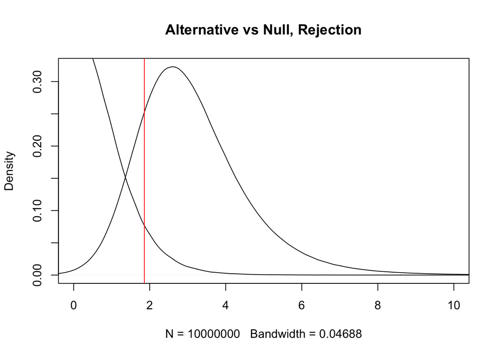

```r
plot(density(rt(10000000,df=8,ncp = sqrt(n/tsample) * delta/sd)),xlim=c(0,10),main="Alternative vs Null, Rejection")
lines(density(rt(1000000,df=8)))
###ncp, or the non-centrality  parameter, is like the deviation of the
abline(v=qt(sig.level/tside, df, lower.tail = FALSE),col="red")
```

Power (0.80) is the area of the alternative curve to the right of the rejection line.

Fortunately, there is code for all of this!

```r
#PowerLVESV
power.t.test(n = 5, d = 55, sig.level = 0.05 ,sd=31,alternative="one.sided")
```

```
##
##      Two-sample t test power calculation
##
##               n = 5
##           delta = 55
##              sd = 31
##       sig.level = 0.05
##           power = 0.8192532
##     alternative = one.sided
##
## NOTE: n is number in *each* group
```

```r
#SWmean
power.t.test(n = 15, d = 2.5, sig.level = 0.05 ,sd=2.6,alternative="one.sided")
```

```
##
##      Two-sample t test power calculation
##
##               n = 15
##           delta = 2.5
##              sd = 2.6
##       sig.level = 0.05
##           power = 0.8222424
##     alternative = one.sided
##
## NOTE: n is number in *each* group
```

```r
##SW_Netherlands

power.t.test(n = 12,d = 2.6, sig.level = 0.05,sd=2.5,alternative="one.sided")
```

```
##
##      Two-sample t test power calculation
##
##               n = 12
##           delta = 2.6
##              sd = 2.5
##       sig.level = 0.05
##           power = 0.7947557
##     alternative = one.sided
##
## NOTE: n is number in *each* group
```

As you can see it preserves confirms everything you’ve computed, althouth the power is slightly different for the SW_Netherlands analysis.